# Project 1

Aspen Saplan et al.

2026-03-08

# Walmart: What Drives Customer Purchases?

#### - S.M.A.R.T Questions:

Which customer, store, time, promotion, weather, and transactional factors are associated with whether a Walmart purchase is an appliance or an electronic product?

This Walmart dataset contains 5000 records of transactions. Each individual record represents one transaction from a customer. Each individual record has a variable attached to the transaction representing what type of item was purchased. That variable is called the category variable and its values are either electronics or appliances. There are many other variables within our dataset, but we limited our investigation down to 14 variables that could have an association with the category variable. Our data set was gathered through the free online platform Kaggle.com. Some analysis that is seen within real world retail companies are studies such as demographic of customers and their locations or seasonal sales trends and promotional effects. Initially with the background of retail analysis we formatted our first try at the smart question based on aggregations such as total revenue and/or average revenue per transaction. However, once we did our exploratory data analysis we started to see these 14 variables could have associations with our category variable. Which led to us abandoning our original smart question, and just working through the exploratory data analysis and the hypothesis testing of all 14 variables. Once we started to see a more clear answer to our unknown question we were able to put what we were looking for on paper. It was hard to initially say our smart question due to having so many variables to look at, but once we analyzed all the variables it was easy to formulate our final smart question. Overall, our research is focused on finding which individual variables have statistical evidence of an association with the variable category being either electronics or appliances.

# 1. Store Location, Customer Loyalty Level, Payment Method, and Customer Income On Category:

## Author of this section: “Aspen Saplan”

## Set up of dataset walmart:

```r
#getwd()
walmart = read.csv("Walmart.csv")
walmart$category = as.factor(walmart$category)
walmart$store_location = as.factor(walmart$store_location)
walmart$customer_loyalty_level = as.factor(walmart$customer_loyalty_level)
walmart$payment_method = as.factor(walmart$payment_method)
print(str(walmart$category))
```

```
##  Factor w/ 2 levels "Appliances","Electronics": 2 2 2 2 2 2 1 2 2 1 ...
## NULL
```

```r
print(str(walmart$store_location))
```

```
##  Factor w/ 5 levels "Chicago, IL",..: 4 2 3 4 1 5 2 3 5 1 ...
## NULL
```

```r
print(str(walmart$customer_loyalty_level))
```

```
##  Factor w/ 4 levels "Bronze","Gold",..: 4 2 3 4 1 1 3 4 3 1 ...
## NULL
```

```r
print(str(walmart$payment_method))
```

```
##  Factor w/ 4 levels "Cash","Credit Card",..: 2 1 1 1 4 2 1 3 2 4 ...
## NULL
```

```r
print(str(walmart$customer_income))
```

```
##  num [1:5000] 98761 69782 77373 33383 108999 ...
## NULL
```

The variables that will be focussed on in this section will be store location, customer loyalty level, payment method, and customer income when comparing to the category variable.

#### - Summary statistics of store location:

```r
summary(walmart$store_location)
```

```
##     Chicago, IL      Dallas, TX Los Angeles, CA       Miami, FL    New York, NY
##            1013             998            1038             964             987
```

#### - Summary statistics of customer loyalty level:

```r
summary(walmart$customer_loyalty_level)
```

```
##   Bronze     Gold Platinum   Silver
##     1253     1160     1299     1288
```

#### - Summary statistics of payment method:

```r
summary(walmart$payment_method)
```

```
##           Cash    Credit Card     Debit Card Digital Wallet
##           1246           1281           1210           1263
```

## EDA:

For the following factor variables I used a grouped bar chart with the number of transactions as the Y axis and the variable as the X axis. I then filled them by which category they were, either appliances or electronics.

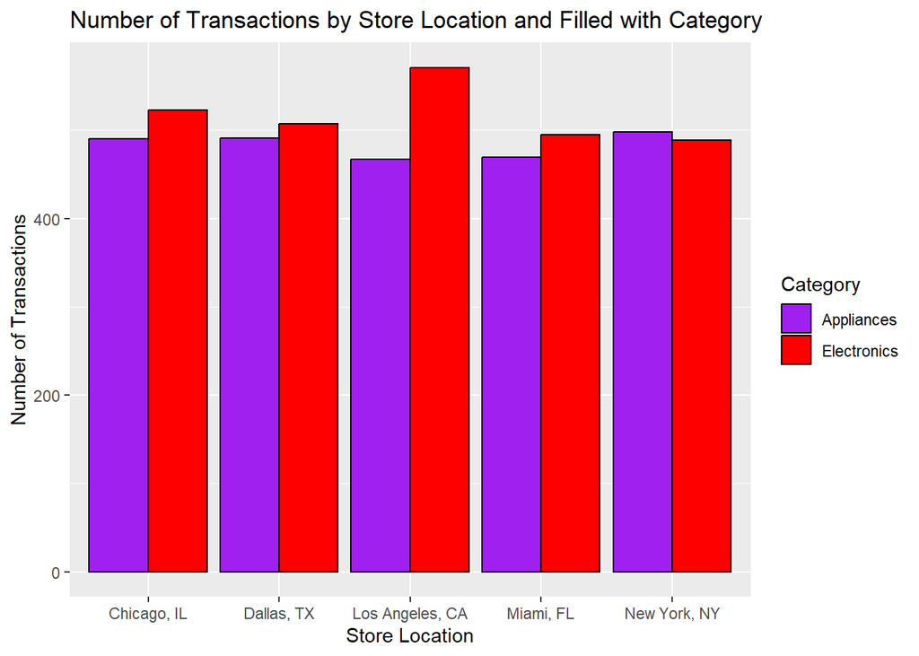

```r
library(ggplot2)
ggplot(walmart, aes(x = store_location, fill = category)) +
  geom_bar(position = "dodge", color = "black")+
  scale_fill_manual(values = c(
    "Appliances" = "purple",
    "Electronics" = "red"
  ))+
  labs(title = "Number of Transactions by Store Location and Filled with Category",
    x = "Store Location",
    y = "Number of Transactions",
    fill = "Category")
```

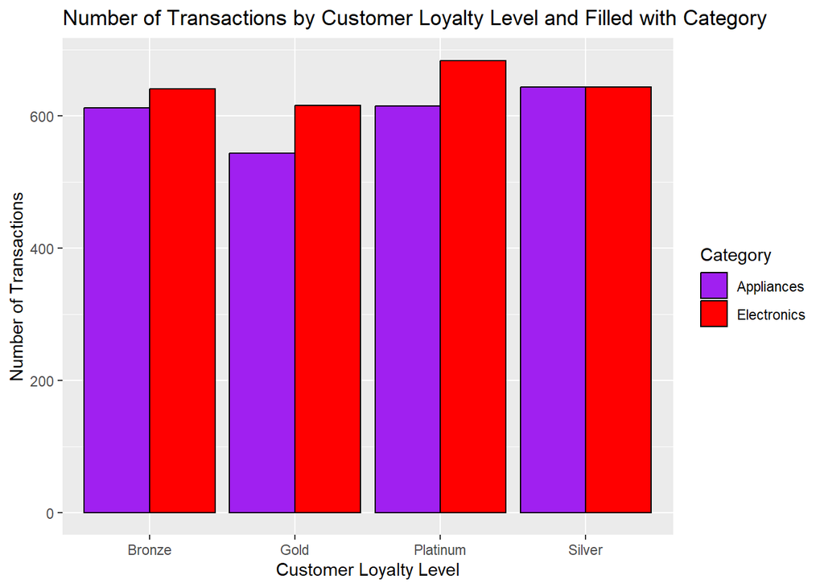

```r
library(ggplot2)
ggplot(walmart, aes(x = customer_loyalty_level, fill = category)) +
  geom_bar(position = "dodge", color = "black")+
  scale_fill_manual(values = c(
    "Appliances" = "purple",
    "Electronics" = "red"
  ))+
  labs(title = "Number of Transactions by Customer Loyalty Level and Filled with Category",
    x = "Customer Loyalty Level",
    y = "Number of Transactions",
    fill = "Category")
```

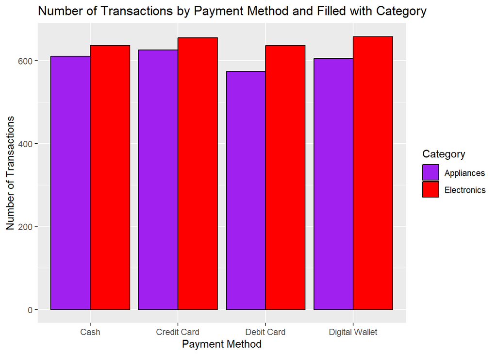

```r
library(ggplot2)
ggplot(walmart, aes(x = payment_method, fill = category)) +
  geom_bar(position = "dodge", color = "black")+
  scale_fill_manual(values = c(
    "Appliances" = "purple",
    "Electronics" = "red"
  ))+
  labs(title = "Number of Transactions by Payment Method and Filled with Category",
    x = "Payment Method",
    y = "Number of Transactions",
    fill = "Category")
```

Looking at the different grouped bar charts that consist of store location, customer loyalty level, and payment method comparing them to the number of transactions filled by the category variable. The electronics transactions have a tendency to exceed the appliance transactions for the most part. There are a few cases such as New York, NY having appliance transactions exceed electronics transactions or the silver customer loyalty level having the same amount of electronic transactions as appliance transactions. So, there is a pattern of electronics transactions out weighing appliance transactions when looking at store location, customer loyalty level, and payment method.

The last variable to be explored in this section is customer income. This variable is numerical so no need to factor it as R will treat this variable correctly. However, I split appliances and electronics transactions into subsets in order to see the distribution for each category by customer income.

#### - Summary of customer income:

```r
summary(walmart$customer_income)
```

```
##    Min. 1st Qu.  Median    Mean 3rd Qu.    Max.
##   20005   44865   70188   70042   95396  120000
```

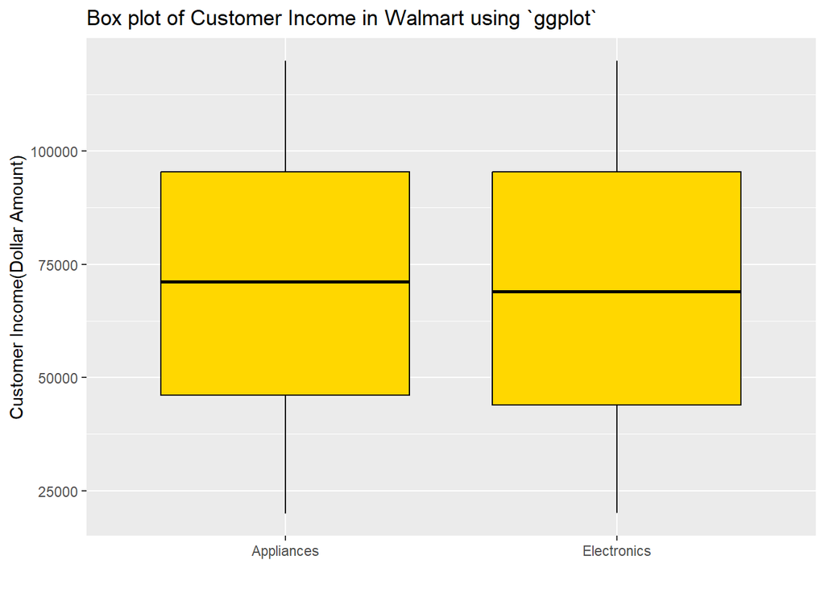

```r
ggplot(walmart, aes(x = category, y=customer_income)) +
  geom_boxplot() +
  geom_boxplot( color="black", fill="gold", outlier.colour="blue", outlier.shape=19, outlier.size=2) +
  labs(title="Box plot of Customer Income in Walmart using `ggplot`", x="", y = "Customer Income(Dollar Amount)")
```

#### - Subset of appliances:

```r
appliances = subset(walmart, category == "Appliances")
print(head(appliances[, c("category", "customer_income")], n=5))
```

```
##      category customer_income
## 7  Appliances        75813.17
## 10 Appliances        44787.70
## 12 Appliances        52253.32
## 13 Appliances        22027.62
## 14 Appliances        65337.53
```

#### - Summary of appliances customer income:

```r
summary(appliances$customer_income)
```

```
##    Min. 1st Qu.  Median    Mean 3rd Qu.    Max.
##   20005   46077   71112   70621   95410  120000
```

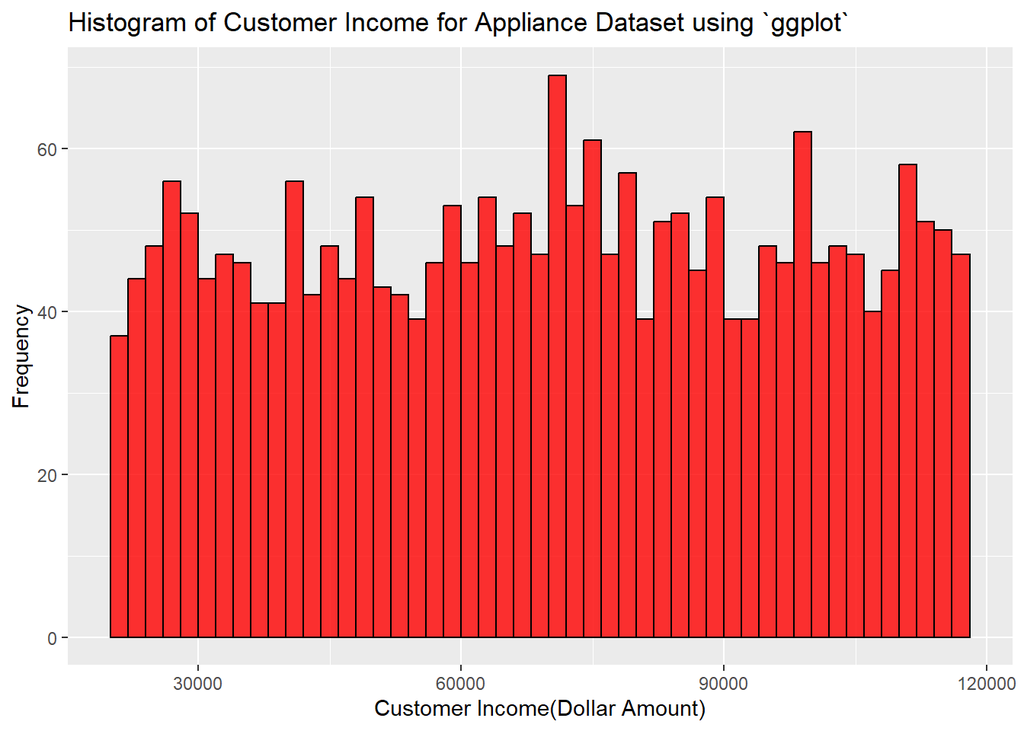

```r
library(ggplot2)
ggplot(data=appliances, aes(customer_income)) +
  geom_histogram(breaks=seq(20005.34, 119999.8, by = 2000),
                 col="black",
                 fill="red",
                 alpha = .8) + # opacity
  labs(x="Customer Income(Dollar Amount)", y="Frequency") +
  labs(title="Histogram of Customer Income for Appliance Dataset using `ggplot`")
```

#### - Subset of electronics:

```r
electronics = subset(walmart, category == "Electronics")
print(head(electronics[, c("category", "customer_income")], n=5))
```

```
##      category customer_income
## 1 Electronics        98760.83
## 2 Electronics        69781.93
## 3 Electronics        77373.10
## 4 Electronics        33383.04
## 5 Electronics       108999.41
```

#### - Summary of electronics customer income:

```r
summary(electronics$customer_income)
```

```
##    Min. 1st Qu.  Median    Mean 3rd Qu.    Max.
##   20029   43940   68939   69500   95355  119998
```

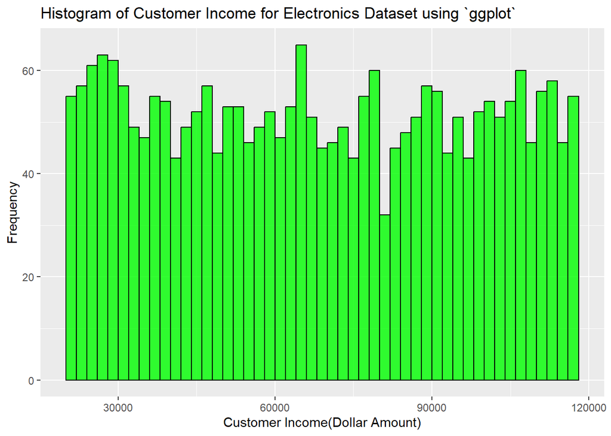

```r
library(ggplot2)
ggplot(data=electronics, aes(customer_income)) +
  geom_histogram(breaks=seq(20028.81, 119997.5, by = 2000),
                 col="black",
                 fill="green",
                 alpha = .8) + # opacity
  labs(x="Customer Income(Dollar Amount)", y="Frequency") +
  labs(title="Histogram of Customer Income for Electronics Dataset using `ggplot`")
```

Looking at both electronics customer income and appliances customer income using a histogram, it suggests that both electronics and appliances have a pretty uniform distribution. Looking at a boxplot of the two categories shows that they have pretty similar descriptive statistics. Thus, through the descriptive statistics there is not a huge pattern or trend regarding customer income and category. The distributions are very similar to each other with no skewing at any value. While the descriptive statistics such as mean, median, and inter quartile ranges are also similar to each other indicating customer income may not have a huge impact on which category is purchased.

## Sketched answer:

My overall quick sketch of an answer to our question would be that customer income most likely will not have an association to the category variable, while the other categorical variables may have an association with the category variable.

## Hypothesis Testing:

A chi-squared test must be used for the store location, customer loyalty level, and payment method variable when testing for independence with the category variable. A chi-squared test must be used due to store location, customer loyalty, and payment method being categorical variables and the category variable being categorical variable as well. First a contingency table has to be made for store location and category, customer loyalty level and category, and payment method and category.

```r
contableSL = table(walmart$category, walmart$store_location)
xkabledply(contableSL, title="Contingency table for category and store_location within walmart dataset")
```

Contingency table for category and store_location within walmart dataset

|  | Chicago, IL | Dallas, TX | Los Angeles, CA | Miami, FL | New York, NY |
| --- | --- | --- | --- | --- | --- |
| Appliances | 490 | 491 | 467 | 469 | 498 |
| Electronics | 523 | 507 | 571 | 495 | 489 |

```r
contableCLL = table(walmart$category, walmart$customer_loyalty_level)
xkabledply(contableCLL, title="Contingency table for category and customer_loyalty_level within walmart dataset")
```

Contingency table for category and customer_loyalty_level within walmart dataset

|  | Bronze | Gold | Platinum | Silver |
| --- | --- | --- | --- | --- |
| Appliances | 612 | 544 | 615 | 644 |
| Electronics | 641 | 616 | 684 | 644 |

```r
contablePM = table(walmart$category, walmart$payment_method)
xkabledply(contablePM, title="Contingency table for category and payment_method within walmart dataset")
```

Contingency table for category and payment_method within walmart dataset

|  | Cash | Credit Card | Debit Card | Digital Wallet |
| --- | --- | --- | --- | --- |
| Appliances | 610 | 626 | 574 | 605 |
| Electronics | 636 | 655 | 636 | 658 |

#### - Test of Independence on category and store_location using contableSL:

Null Hypothesis: Category and store_location are independent

Alternative Hypothesis: Category and store_location are not independent

Alpha = 0.05

```r
chitestSL = chisq.test(contableSL)
chitestSL
```

```
##
##  Pearson's Chi-squared test
##
## data:  contableSL
## X-squared = 6.7627, df = 4, p-value = 0.149
```

After running our chi-squared test on store location and category we can see that our p-value returned is 0.149. Comparing our p-value(0.149) and our alpha value(0.05) we can see that the p-value is greater than alpha. Thus, since our p-value is greater than our alpha value we fail to reject the null hypothesis, which provides evidence suggesting that store location and category are independent and have no association.

#### - Test of Independence on category and customer_loyalty_level using contableCLL:

Null Hypothesis: Category and customer_loyalty_level are independent

Alternative Hypothesis: Category and customer_loyalty_level are not independent

Alpha = 0.05

```r
chitestCLL = chisq.test(contableCLL)
chitestCLL
```

```
##
##  Pearson's Chi-squared test
##
## data:  contableCLL
## X-squared = 3.0288, df = 3, p-value = 0.3872
```

After running our chi-squared test on customer loyalty level and category we can see that our p-value returned is 0.3872. Comparing our p-value(0.3872) and our alpha value(0.05) we can see that the p-value is greater than alpha. Thus, since our p-value is greater than our alpha value we fail to reject the null hypothesis, which provides evidence suggesting that customer loyalty level and category are independent and have no association.

#### - Test of Independence on category and payment_method using contablePM:

Null Hypothesis: Category and payment_method are independent

Alternative Hypothesis: Category and payment_method are not independent

Alpha = 0.05

```r
chitestPM = chisq.test(contablePM)
chitestPM
```

```
##
##  Pearson's Chi-squared test
##
## data:  contablePM
## X-squared = 0.82093, df = 3, p-value = 0.8445
```

After running our chi-squared test on payment method and category we can see that our p-value returned is 0.8445. Comparing our p-value(0.8445) and our alpha value(0.05) we can see that the p-value is greater than alpha. Thus, since our p-value is greater than our alpha value we fail to reject the null hypothesis, which provides evidence suggesting that payment method and category are independent and have no association.

For the customer income variable I started by separating appliance transactions and electronics transactions into two subsets. Knowing that customer income is a numerical variable I know that a two sample t-test is needed for this hypothesis test.

#### - T-Test of customer_income and category:

Null Hypothesis: Customer_income means are equal for appliances and electronics

Alternative Hypothesis: Customer_income means are not equal for appliances and electronics

Alpha = 0.05

```r
ttestCI = t.test(appliances$customer_income, electronics$customer_income)
ttestCI
```

```
##
##  Welch Two Sample t-test
##
## data:  appliances$customer_income and electronics$customer_income
## t = 1.3643, df = 4990.2, p-value = 0.1725
## alternative hypothesis: true difference in means is not equal to 0
## 95 percent confidence interval:
##  -489.6096 2730.8529
## sample estimates:
## mean of x mean of y
##  70620.99  69500.37
```

After running the t-test on appliances customer income and electronics customer income we can see that our p-value returned is 0.1725. Comparing our p-value(0.1725) and our alpha value(0.05) we can see that the p-value is greater than alpha. Thus, since our p-value is greater than our alpha we fail to reject the null hypothesis. So, the evidence does not suggest that an average higher or lower income is associated with purchasing electronics over appliances and vice versa.

## Outcome:

Through different hypothesis testing on these variables of store location, customer loyalty level, payment method, and customer income. The data suggests that all the variables are either independent or share the same population mean when compared with the variable category.

# 2. Day of the week, holidays, and type of weather considered against total sales and sales by category

## Author of this section: Alex Rizzo-Banks

Each of the following variables will be compared against the variable “category” to tell us if the given variables influence preference toward appliances or electronics or if they show a dependence between number of transactions (also mentioned as “sales” herein):

#### A. “weekday” is a character variable with the days of the week as levels. We have used the factor() function to order them 1-7 starting with “Monday”.

```r
walmart$weekday = factor(walmart$weekday, levels = c("Monday", "Tuesday", "Wednesday", "Thursday", "Friday", "Saturday", "Sunday"), ordered = TRUE)
str(walmart$weekday)
```

```
##  Ord.factor w/ 7 levels "Monday"<"Tuesday"<..: 5 1 2 7 4 6 7 4 6 1 ...
```

#### B. “holiday_indicator” is a binary logical variable that was recorded as TRUE for transactions taking place on a holiday.

```r
str(walmart$holiday_indicator)
```

```
##  logi [1:5000] FALSE FALSE FALSE TRUE FALSE TRUE ...
```

#### C. “weather_conditions” is a character variable with four levels: “Sunny”, “Cloudy”, “Rainy”, and “Stormy”. These are not ordered.

```r
walmart$weather_conditions = factor(walmart$weather_conditions, levels = c("Stormy", "Rainy", "Sunny", "Cloudy"), ordered = FALSE)
unique(walmart$weather_conditions)
```

```
## [1] Stormy Rainy  Sunny  Cloudy
## Levels: Stormy Rainy Sunny Cloudy
```

## EDA

First, Let’s expand the “holiday_indicator” category next to the transaction dates to figure out if these are only national holidays or a larger set.

```r
HOLIDAYS = data.frame(walmart$transaction_date, walmart$holiday_indicator)
xkabledplyhead(HOLIDAYS, rows = 15, title = "Holidays by transaction date")
```

Holidays by transaction date

| walmart.transaction_date | walmart.holiday_indicator |
| --- | --- |
| 3/31/2024 21:46 | FALSE |
| 7/28/2024 12:45 | FALSE |
| 6/10/2024 4:55 | FALSE |
| 8/15/2024 1:03 | TRUE |
| 9/13/2024 0:45 | FALSE |
| 7/6/2024 7:24 | TRUE |
| 3/17/2024 22:33 | FALSE |
| 7/22/2024 13:57 | TRUE |
| 3/30/2024 4:10 | TRUE |
| 6/17/2024 16:59 | TRUE |
| 4/3/2024 11:37 | FALSE |
| 6/19/2024 10:41 | TRUE |
| 3/1/2024 4:08 | TRUE |
| 6/24/2024 17:34 | TRUE |
| 7/11/2024 11:58 | FALSE |

We can see from the HOLIDAYS DataFrame that these holidays likely refer to promotional periods run by Walmart surrounding national and other holidays such as July 4th, Juneteenth, etc, rather than single days. However, we would need more data or another document to confirm this, such as a Walmart internal schedule or historical list of holidays observed by the store (These days are obviously not days where the store closes, as they are days where transactions took place).

### Bar Charts

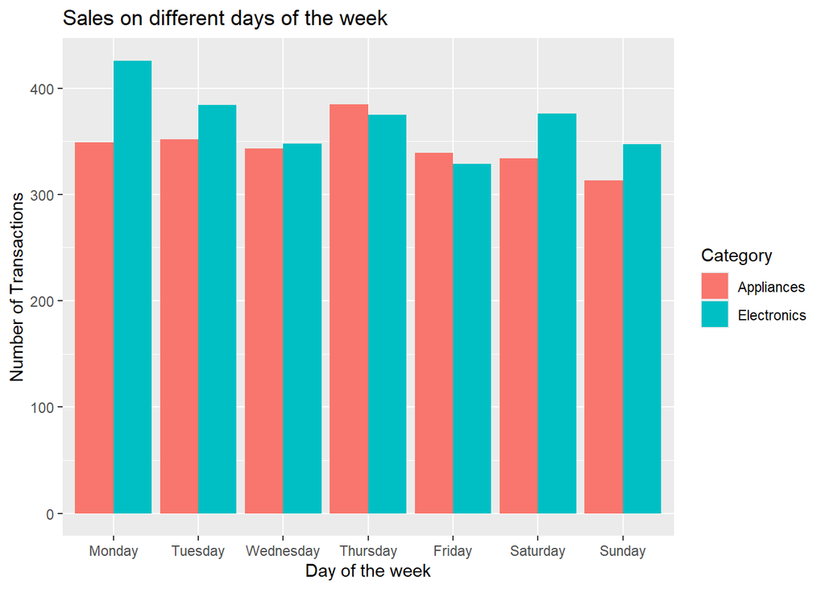

```r
ggplot(walmart, aes(x = weekday, fill = category)) + geom_bar(position = "dodge") + labs(x = "Day of the week", y = "Number of Transactions",title = "Sales on different days of the week", fill= "Category")
```

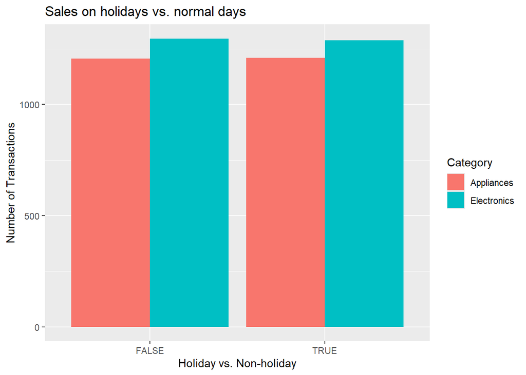

```r
ggplot(walmart, aes(x = holiday_indicator,  fill = category)) + geom_bar(position = "dodge") + labs(x = "Holiday vs. Non-holiday", y = "Number of Transactions", title = "Sales on holidays vs. normal days", fill = "Category", )
```

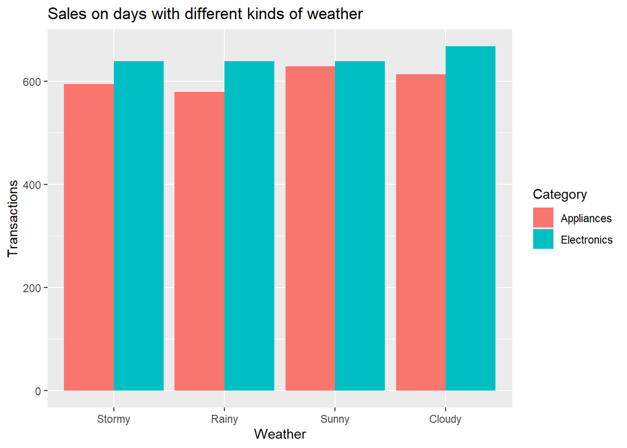

```r
ggplot(walmart, aes(x = weather_conditions, fill = category)) + geom_bar(position = "dodge") + labs(x = "Weather", y = "Transactions", title = "Sales on days with different kinds of weather", fill = "Category")
```

There is no clear trend indicating that any of the three qualifiers affect the sales of electronics versus appliances, though we do see that electronics noticeably outsell appliances on Mondays. Overall, electronics sell better but not by much. Next we’ll use Chi tests to confirm whether these variables have an impact on category value or not.

## Hypothesis Testing

First, we’ll need to create a contingency table for each variable paired with category.

```r
contabwk = table(walmart$category, walmart$weekday)
contabhol = table(walmart$category, walmart$holiday_indicator)
contabwthr = table(walmart$category, walmart$weather_conditions)
```

#### Contingency Table for Category and Day of the Week

```r
xkabledply(contabwk, title = "Contingency Table: Category + Day of the Week")
```

Contingency Table: Category + Day of the Week

|  | Monday | Tuesday | Wednesday | Thursday | Friday | Saturday | Sunday |
| --- | --- | --- | --- | --- | --- | --- | --- |
| Appliances | 349 | 352 | 343 | 385 | 339 | 334 | 313 |
| Electronics | 426 | 384 | 348 | 375 | 329 | 376 | 347 |

#### Contingency Table for Category and Holiday Indicator

```r
xkabledply(contabhol, title = "Contingency Table: Category + Holiday Indicator")
```

Contingency Table: Category + Holiday Indicator

|  | FALSE | TRUE |
| --- | --- | --- |
| Appliances | 1205 | 1210 |
| Electronics | 1296 | 1289 |

#### Contingency Table for Category and Type of Weather

```r
xkabledply(contabwthr, title = "Contingency Table: Category + Type of Weather")
```

Contingency Table: Category + Type of Weather

|  | Stormy | Rainy | Sunny | Cloudy |
| --- | --- | --- | --- | --- |
| Appliances | 594 | 579 | 629 | 613 |
| Electronics | 639 | 639 | 639 | 668 |

### A. Testing Day of the Week

For (A), our alpha value is 0.05. Our null hypothesis is that day of the week has no impact on whether electronics or appliances sell better than the other. Our alternative hypothesis is that the day of the week will have some correlation with the category that sells better.

```r
chitestwk = chisq.test(contabwk)
chitestwk
```

```
##
##  Pearson's Chi-squared test
##
## data:  contabwk
## X-squared = 7.8242, df = 6, p-value = 0.2513
```

### B. Testing Holidays vs. Non-holidays

For (B) our alpha value will be 0.05 and our null hypothesis is that the day of sale being holiday does not impact whether electronics or appliances outsells the other. Our alternative hypothesis is that the presence of a holiday or a non-holiday will show some impact on which level of the category variable records more transactions.

```r
chitesthol = chisq.test(contabhol)
chitesthol
```

```
##
##  Pearson's Chi-squared test with Yates' continuity correction
##
## data:  contabhol
## X-squared = 0.019752, df = 1, p-value = 0.8882
```

### C. Testing Type of Weather

For (C) our alpha value will be 0.05 and our null hypothesis is that the type of weather has no impact on whether electronics or appliances sells better that day. Our alternative hypothesis is that the type of whether will show some impact on which level of the category variable records more transactions.

```r
chitestwthr = chisq.test(contabwthr)
chitestwthr
```

```
##
##  Pearson's Chi-squared test
##
## data:  contabwthr
## X-squared = 1.2598, df = 3, p-value = 0.7387
```

### 2 - Conclusions

For variable A - day of the week, we report a p-value of 0.25. Since this is higher than our alpha level, we fail to reject the null hypothesis; in other words, there does not appear to be any correlation between the day of the week and the strength of appliance sales vs. electronics sales.

For variable B - holiday presence, we report a p-value of 0.89. This is similarly higher than our alpha level, so we once again fail to reject the null hypothesis; whether or not a transaction takes place on a Walmart-recorded holiday does not seem to influence whether that purchase is more likely to be an appliance or electronics.

Finally, for variable C - type of weather, we report a p-value of 0.74. Once again, this value is higher than our alpha level and we fail to reject our null hypothesis. There does not appear to be any correlation between the type of weather and the category of device that a customer chooses to purchase.

[output not shown]

The csv file is converted into a dataframe called walmart. customer_age, unit_price, quantity_sold are converted into a numeric format that doesn’t change the walmart dataset. These converted variables are stored separately. Customer_gender and category are changed into categorical and stored separately as well.

## Checking if NA values exist in the variables

```r
colSums(is.na(walmart))
```

```
##         transaction_id            customer_id             product_id
##                      0                      0                      0
##           product_name               category          quantity_sold
##                      0                      0                      0
##             unit_price       transaction_date               store_id
##                      0                      0                      0
##         store_location        inventory_level          reorder_point
##                      0                      0                      0
##       reorder_quantity            supplier_id     supplier_lead_time
##                      0                      0                      0
##           customer_age        customer_gender        customer_income
##                      0                      0                      0
## customer_loyalty_level         payment_method      promotion_applied
##                      0                      0                      0
##         promotion_type     weather_conditions      holiday_indicator
##                      0                      0                      0
##                weekday     stockout_indicator      forecasted_demand
##                      0                      0                      0
##          actual_demand
##                      0
```

this is used to check for any values that are read as NA. The code output suggests that there are no NA values so it won’t skew the data.

## Summary statistics

```
##   customer_age     category         quantity_sold     unit_price
##  Min.   :18.00   Length:5000        Min.   :1.000   Min.   :  50.1
##  1st Qu.:31.00   Class :character   1st Qu.:2.000   1st Qu.: 537.8
##  Median :44.00   Mode  :character   Median :3.000   Median :1029.2
##  Mean   :44.12                      Mean   :2.983   Mean   :1023.5
##  3rd Qu.:58.00                      3rd Qu.:4.000   3rd Qu.:1506.3
##  Max.   :70.00                      Max.   :5.000   Max.   :1999.8
##  customer_gender
##  Length:5000
##  Class :character
##  Mode  :character
##
##
##
```

This command gives a summary of the files listed in the vector w. this provides summary statistics such as median, mean, and the quartiles for the numeric variables. As for the categorical variables, length is provided and types.

## Exploratory data analysis.

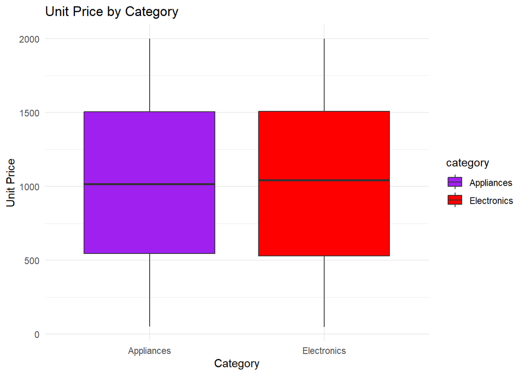

```r
#EDA of total revenue for appliances and electronics
library(ggplot2)


ggplot(walmart, aes(x = category, y = unit_price, fill = category)) +
  geom_boxplot() +
  scale_fill_manual(values = c("Appliances" = "purple",
                               "Electronics" = "red")) +
  labs(title = "Unit Price by Category",
       x = "Category",
       y = "Unit Price") +
  theme_minimal()
```

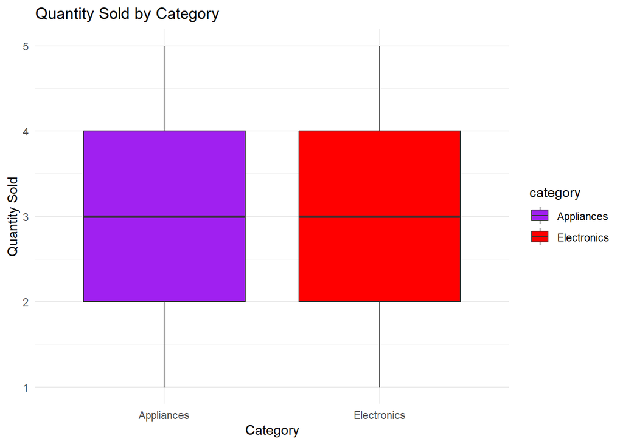

```r
ggplot(walmart, aes(x = category, y = quantity_sold, fill = category)) +
  geom_boxplot() +
  scale_fill_manual(values = c("Appliances" = "purple",
                               "Electronics" = "red")) +
  labs(title = "Quantity Sold by Category",
       x = "Category",
       y = "Quantity Sold") +
  theme_minimal()
```

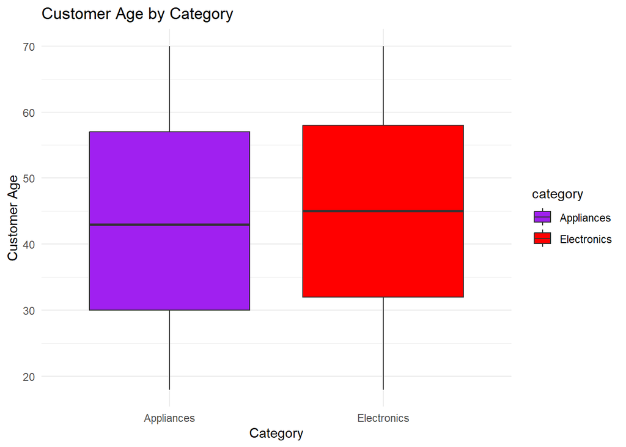

```r
ggplot(walmart, aes(x = category, y = customer_age, fill = category)) +
  geom_boxplot() +
  scale_fill_manual(values = c("Appliances" = "purple",
                               "Electronics" = "red")) +
  labs(title = "Customer Age by Category",
       x = "Category",
       y = "Customer Age") +
  theme_minimal()
```

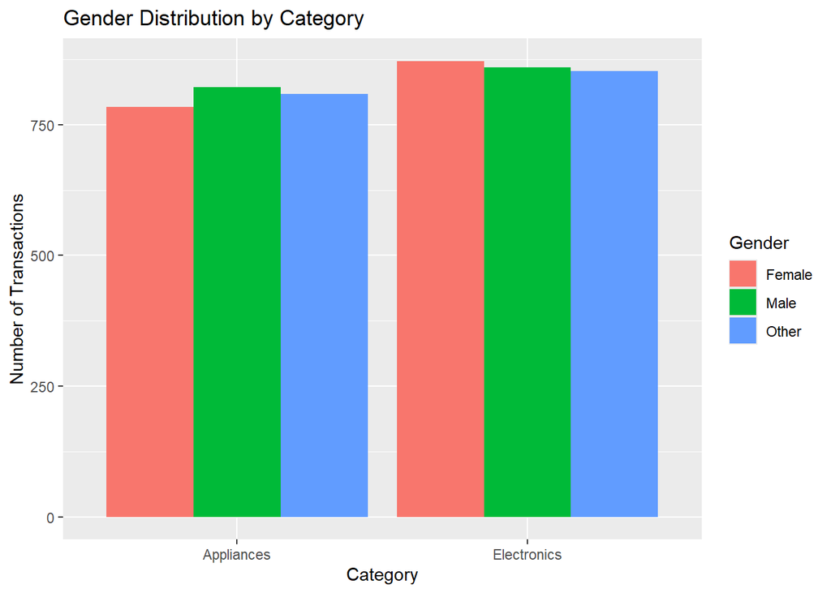

```r
ggplot(walmart, aes(x = category, fill = customer_gender)) +
  geom_bar(position = "dodge") +
  labs(title = "Gender Distribution by Category",
       x = "Category",
       y = "Number of Transactions",
       fill = "Gender")
```

The data looks very similar across all of the plots. EDA is conducted to see data distribution among the four variables across the two categories, Appliances and electronics. The data seems to equally distributed in a plots, with no favoritism to one category.

## Hypothesis testing using chi-square test of independence and welch t-tests.

```r
t.test(unit_price ~ category, data = walmart)
```

```
##
##  Welch Two Sample t-test
##
## data:  unit_price by category
## t = -0.010478, df = 4978.2, p-value = 0.9916
## alternative hypothesis: true difference in means between group Appliances and group Electronics is not equal to 0
## 95 percent confidence interval:
##  -31.21221  30.88033
## sample estimates:
##  mean in group Appliances mean in group Electronics
##                  1023.382                  1023.547
```

```r
t.test(quantity_sold ~ category, data = walmart)
```

```
##
##  Welch Two Sample t-test
##
## data:  quantity_sold by category
## t = -0.6874, df = 4984.1, p-value = 0.4919
## alternative hypothesis: true difference in means between group Appliances and group Electronics is not equal to 0
## 95 percent confidence interval:
##  -0.10631955  0.05111654
## sample estimates:
##  mean in group Appliances mean in group Electronics
##                  2.968530                  2.996132
```

```r
t.test(customer_age ~ category, data = walmart)
```

```
##
##  Welch Two Sample t-test
##
## data:  customer_age by category
## t = -3.4383, df = 4974.2, p-value = 0.0005901
## alternative hypothesis: true difference in means between group Appliances and group Electronics is not equal to 0
## 95 percent confidence interval:
##  -2.3397019 -0.6404791
## sample estimates:
##  mean in group Appliances mean in group Electronics
##                  43.35362                  44.84371
```

```r
contable_gender = table(walmart$category, walmart$customer_gender)
chisq.test(contable_gender)
```

```
##
##  Pearson's Chi-squared test
##
## data:  contable_gender
## X-squared = 0.92076, df = 2, p-value = 0.631
```

The first code creates a contingency table, which shows how many observations fall into a combination of categories and customer_gender. A chi-square test of independence is used to show whether gender and categories are independent of each other. This means that the null hypothesis would be that gender and category are independent of each other and that both categories have equal distributions of gender. Since 0.631 is higher than 0.5, we fail to reject the null hypothesis

```r
knitr::opts_chunk$set(echo=TRUE, message=FALSE, warning=FALSE)
library(tidyverse)
library(lubridate)
library(janitor)
library(effsize)
library(dplyr)
```

## Data Preparation

Clean column names

```r
walmart <- walmart %>% clean_names()
```

## Keep original transaction_date in a RAW column

```r
walmart <- walmart %>%
  mutate(
    transaction_date_raw = transaction_date,
    category = as.factor(category),
    promotion_applied = as.factor(promotion_applied),
    promotion_type = as.factor(promotion_type)
  )
```

Robust date parsing (handles multiple formats + optional timestamps) We create a NEW column transaction_date_clean so we never break the original

```r
walmart <- walmart %>%
  mutate(
    transaction_date_clean = parse_date_time(
      transaction_date_raw,
      orders = c("mdy", "dmy", "ymd", "mdy HMS", "dmy HMS", "ymd HMS"),
      quiet = TRUE
    ),
    transaction_date_clean = as.Date(transaction_date_clean)
  )
```

Quick check

```r
summary(walmart$transaction_date_clean)
```

```
##    Min. 1st Qu.  Median    Mean 3rd Qu.    Max.    NA's
##      NA      NA      NA   "NaN"      NA      NA  "5000"
```

```r
sum(is.na(walmart$transaction_date_clean))
```

```
## [1] 5000
```

## Binary indicator: 1 = Electronics, 0 = Appliances

```r
walmart <- walmart %>%
  mutate(category_bin = if_else(category == "Electronics", 1, 0))
```

## EDATransaction Date

[figure not shown]

```r
walmart %>%
  filter(!is.na(transaction_date_clean)) %>%
  count(transaction_date_clean) %>%
  ggplot(aes(x = transaction_date_clean, y = n)) +
  geom_line(color = "gray40", linewidth = 0.6) +
  geom_smooth(method = "loess", color = "#E15759", linewidth = 1.2, se = FALSE) +
  labs(
    title = "Number of Transactions Over Time",
    x = "Transaction Date",
    y = "Number of Transactions"
  ) +
  theme_minimal()
```

## EDA: Proportion of Electronics by Promotion Applied

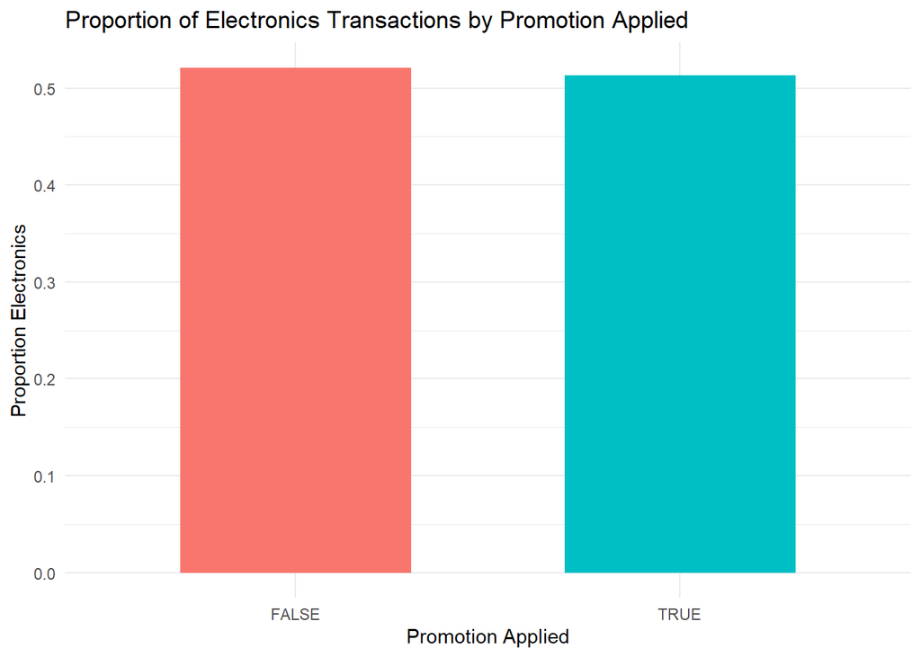

```r
walmart %>%
  group_by(promotion_applied) %>%
  summarise(
    prop_electronics = mean(category_bin),
    n = n(),
    .groups = "drop"
  ) %>%
  ggplot(aes(x = promotion_applied, y = prop_electronics, fill = promotion_applied)) +
  geom_col(width = 0.6) +
  labs(
    title = "Proportion of Electronics Transactions by Promotion Applied",
    x = "Promotion Applied",
    y = "Proportion Electronics"
  ) +
  theme_minimal() +
  theme(legend.position = "none")
```

The bar chart compares the proportion of Electronics transactions between purchases with and without promotions. The proportions are nearly identical across both groups, with approximately 52% of transactions belonging to Electronics when no promotion is applied and about 51% when a promotion is present. This suggests that applying a promotion does not substantially influence whether a transaction belongs to the Electronics or Appliances category.

```r
t.test(category_bin ~ promotion_applied, data = walmart)
```

```
##
##  Welch Two Sample t-test
##
## data:  category_bin by promotion_applied
## t = 0.5562, df = 4962, p-value = 0.5781
## alternative hypothesis: true difference in means between group FALSE and group TRUE is not equal to 0
## 95 percent confidence interval:
##  -0.01986868  0.03560791
## sample estimates:
## mean in group FALSE  mean in group TRUE
##           0.5211032           0.5132336
```

Null Hypothesis (H0): The proportion of Electronics transactions is the same for transactions with promotions and without promotions.

Alternative Hypothesis (H1): The proportion of Electronics transactions differs between transactions with promotions and without promotions.

Test Results and Interpretation

A Welch two-sample t-test was conducted to compare the proportion of Electronics transactions between purchases with and without promotions.

The results show no statistically significant difference between the two groups (t = 0.556, p = 0.578). Transactions without promotions had an Electronics proportion of 52.1%, while transactions with promotions had a proportion of 51.3%.

The 95% confidence interval [-0.0199, 0.0356] includes zero, indicating that the true difference in proportions may be zero. Therefore, we fail to reject the null hypothesis.

Overall, the data provide no statistical evidence that applying a promotion changes the likelihood that a transaction belongs to the Electronics category rather than Appliances.

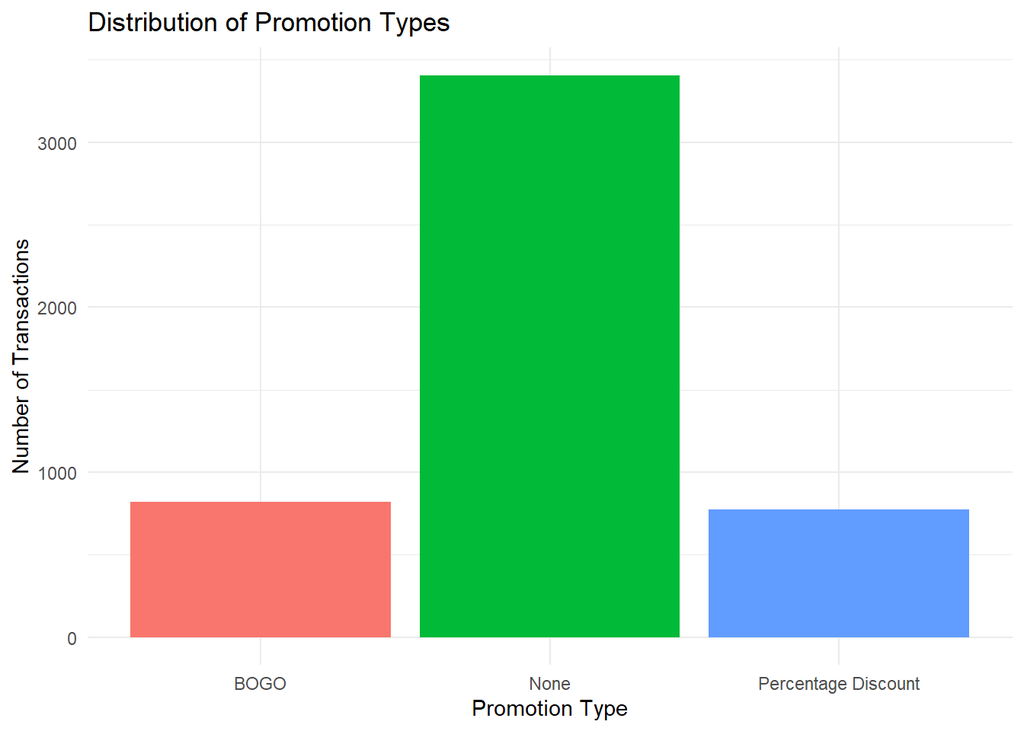

```r
walmart %>%
  count(promotion_type) %>%
  ggplot(aes(x = promotion_type, y = n, fill = promotion_type)) +
  geom_col() +
  labs(
    title = "Distribution of Promotion Types",
    x = "Promotion Type",
    y = "Number of Transactions"
  ) +
  theme_minimal() +
  theme(legend.position = "none")
```

The bar chart shows the number of transactions associated with each promotion type. The majority of transactions in the dataset occur without a promotion, while BOGO and Percentage Discount promotions appear less frequently and at similar levels. This distribution indicates that promotional strategies are used in a smaller portion of transactions compared to purchases with no promotion applied.

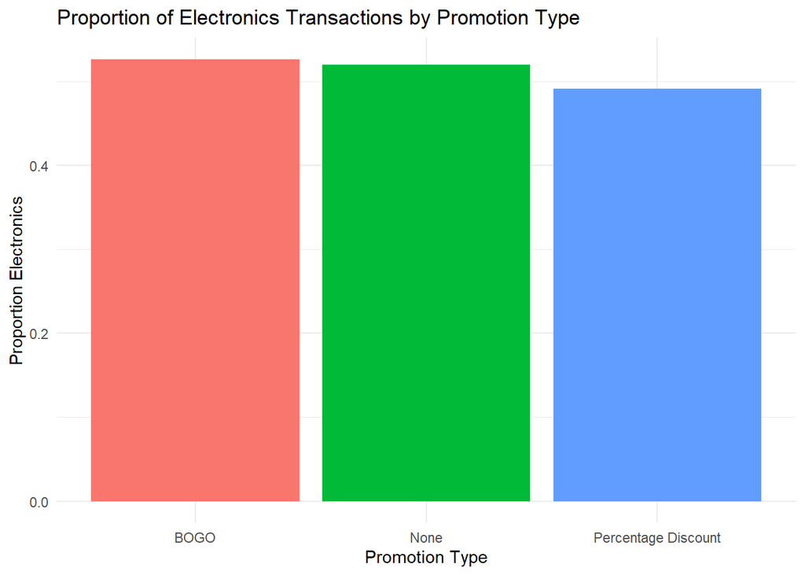

```r
walmart %>%
  group_by(promotion_type) %>%
  summarise(prop_electronics = mean(category_bin),
            n = n(),
            .groups = "drop") %>%
  ggplot(aes(x = promotion_type, y = prop_electronics, fill = promotion_type)) +
  geom_col() +
  labs(
    title = "Proportion of Electronics Transactions by Promotion Type",
    x = "Promotion Type",
    y = "Proportion Electronics"
  ) +
  theme_minimal() +
  theme(legend.position = "none")
```

The bar chart shows the proportion of transactions that belong to the Electronics category across different promotion types. The proportions appear very similar across all promotion types. BOGO promotions show the slightly highest proportion of Electronics purchases, followed by transactions with no promotion, while Percentage Discount promotions show the lowest proportion. However, the differences are small, suggesting that promotion type may not strongly influence whether customers purchase Electronics versus Appliances.

```r
# Contingency table
table(walmart$promotion_type, walmart$category)
```

```
##
##                       Appliances Electronics
##   BOGO                       388         432
##   None                      1634        1773
##   Percentage Discount        393         380
```

```r
# Chi-square test
chisq.test(walmart$promotion_type, walmart$category)
```

```
##
##  Pearson's Chi-squared test
##
## data:  walmart$promotion_type and walmart$category
## X-squared = 2.4734, df = 2, p-value = 0.2903
```

Hypothesis Test: Promotion Type and Product Category

To determine whether promotion type influences the type of product purchased (Electronics vs Appliances), a Chi-square test of independence was conducted.

Null Hypothesis (H0): The product category purchased (Electronics vs Appliances) is independent of the promotion type.

Alternative Hypothesis (H1): The product category purchased (Electronics vs Appliances) depends on the promotion type.

The contingency table shows the number of transactions by promotion type and product category. For example, BOGO promotions resulted in 388 Appliances purchases and 432 Electronics purchases, while transactions with no promotion resulted in 1634 Appliances purchases and 1773 Electronics purchases.

The Pearson Chi-square test produced a p-value of 0.2903, which is greater than the significance level of 0.05. Therefore, we fail to reject the null hypothesis.

This result suggests that there is no statistically significant relationship between promotion type and whether customers purchase Electronics or Appliances. The proportions of Electronics purchases appear relatively similar across BOGO, Percentage Discount, and transactions with no promotion, which is consistent with the patterns observed in the exploratory data analysis.

# Conclusion

Though our initial EDA seemed to suggest some light correlation between certain variables (store location, day of the week, and customer gender), our hypothesis testing delivered the null result in almost every comparison except for customer age, where we were able to reject the null hyothesis with a p-value of 0.0005. Excepting customer age, none of our tested variables can be said to reliably produce an impact on whether a customer purchased from the electronics category or the appliances category.

However, when considering the limitations of the data set, several observations must be made. First, that almost all of our bar charts displayed roughly equal counts for the levels of each variable is statistically improbable and raises questions pertaining to how the data points (ie. the 5000 transactions) were collected.

```r
summary(walmart$holiday_indicator)
```

```
##    Mode   FALSE    TRUE
## logical    2501    2499
```

```r
summary(walmart$weekday)
```

```
##    Length     Class      Mode
##      5000 character character
```

Secondly, the data points as recorded do not obey the intuitive reasoning and understanding of store categorizations in the real world. A prime example of this phenomena is the interaction between the ‘product name’ and ‘category’ variable:

## Product names by category

```r
Conclusion1 = table(walmart$product_name, walmart$category)
Conclusion1
```

```
##
##                   Appliances Electronics
##   Camera                 304         324
##   Fridge                 319         336
##   Headphones             278         336
##   Laptop                 292         286
##   Smartphone             316         325
##   Tablet                 321         326
##   TV                     298         325
##   Washing Machine        287         327
```

As we can see, roughly half of the time a product with the name “Camera” is listed as an appliance, as are those named “TV” and “Laptop”. This may point to erroneously catalogued data and we elected not to consider product name in our investigation for this reason.

Finally, it is not plausible to assume that over a span of nine months (1/1/2024 - 9/16/2024) and five stores, only 5000 transactions took place for the largest retailer in the world, so it would be helpful to know what additional filtering variable the author used to assemble these 5000 observations (it is functionally impossible that they were randomly chosen given the proportions seen above for variables like day of the week).

# References

ANKIT RAJ MISHRA, “walmart” (2025). Data set, Kaggle.com. Lcense: Apache 2.0